# Differential Gene Expression (DGE) Analysis using DESeq2

Pulmonary Adenocarcinoma Vs Nearby Healthy Tissue (univolved)

Tundup Namgail

November 21, 2025

DESeq2 uses a statistical model based on the negative binomial distribution to identify genes that show significant differences in expression between experimental conditions (for example, Control vs. PulmoAD).

In this tutorial, we’ll perform Differential Expression Analysis (DEA) using the DESeq2 package in R. The goal is to identify genes that are significantly upregulated or downregulated between the two conditions (Control and PulmoAD) using RNA-Seq count data generated in the previous preprocessing tutorial.

All analyses in this tutorial have been conducted in RStudio. Make sure you have both R and RStudio installed. You can download and install them by following the instructions available here: https://posit.co/download/rstudio-desktop/

### 1.Install required libraries with BiocManager

Before any analysis, install all the necessary packages that will be used throughout the workflow. R’s Bioconductor repository hosts specialized bioinformatics tools. DESeq2 and other packages are maintained there to ensure reproducibility and compatibility.

```r
if (!requireNamespace("BiocManager", quietly = TRUE))
  install.packages("BiocManager")

BiocManager::install(c("DESeq2", "EnhancedVolcano", "org.Hs.eg.db", "pheatmap"))
```

Packages installed:

-DESeq2: Core package for normalization, dispersion estimation, and statistical testing.

-EnhancedVolcano: For visually intuitive volcano plots.

-org.Hs.eg.db: Human gene annotation database (Ensembl ↔︎ Gene Symbol mapping).

-pheatmap: For heat map visualization

Note: Run this only once on your system. Skip re-installation during future sessions.

### 2. Load libraries

Loading the installed packages makes their functions available for use in your current R session. Without loading, R won’t recognize the functions (e.g., DESeq() or EnhancedVolcano()).

```r
library(DESeq2)
library(EnhancedVolcano)
library(org.Hs.eg.db)
library(pheatmap)
```

This loads all required R libraries into your session so their functions can be used. If you get an error like “package not found,” rerun Step 1 to install it.

### 3. Set working Directory

This tells R where to look for your files and where to save outputs. Setting this ensures that R reads and writes data files without needing to repeatedly specify full file paths. Replace the path with your own directory containing the count matrix file.

```r
setwd("~/Downloads/Workshop")
getwd()
```

```
[1] "/Users/tundup/Downloads/Workshop"
```

Note: Always confirm your path with getwd(). If your count file is not found, double- check that it is located in this directory.

### 4. Load Count Matrix

The count matrix contains raw read counts obtained from RNA-seq read quantification tools like featureCounts (in this tutorial), HTSeq, or Salmon. DESeq2 requires raw counts because it uses the negative binomial model that depends on integer count distributions. Expected format: Rows: Genes (usually Ensembl IDs), Columns: Samples, Values: Raw integer counts (untransformed, unnormalized)

```r
counts_mtx <- read.table("merged_counts_clean.txt",
                         header = TRUE,
                         row.names = 1,
                         sep = "\t",
                         check.names = FALSE)


# Check the count matrix
head(counts_mtx)
```

|  | SRR11262284 | SRR11262285 | SRR11262286 | SRR11262292 | SRR11262293 | SRR11262294 |
| --- | --- | --- | --- | --- | --- | --- |
| ENSG00000160072 | 547 | 559 | 599 | 1797 | 3496 | 1902 |
| ENSG00000279928 | 0 | 0 | 0 | 4 | 0 | 0 |
| ENSG00000228037 | 12 | 8 | 6 | 6 | 6 | 28 |
| ENSG00000142611 | 683 | 283 | 478 | 150 | 8 | 34 |
| ENSG00000284616 | 0 | 0 | 0 | 0 | 0 | 0 |
| ENSG00000157911 | 638 | 598 | 707 | 693 | 657 | 544 |

```r
dim(counts_mtx)
```

```
[1] 62710     6
```

Note: If your count data are already log-transformed or normalized (e.g., TPM, FPKM), they cannot be used with DESeq2.

### 5. Create metadata

The metadata (or colData) describes each sample and its corresponding condition (e.g., Control vs. Disease). DESeq2 uses this data frame to understand which samples belong to which experimental group when fitting the model. The sample names in colData must match exactly the column names in the count matrix. Example - If your count matrix columns are named differently (e.g., “sample1”, “sample2”), update the sample_names vector accordingly.

```r
sample_names <- c("SRR11262284", "SRR11262285", "SRR11262286",
                  "SRR11262292", "SRR11262293", "SRR11262294")

condition <- c("Control", "Control", "Control",
               "PulmoAD", "PulmoAD", "PulmoAD")

# Combine into a data frame
colData <- data.frame(Sample = sample_names,
                      Group = condition,
                      stringsAsFactors = FALSE)

# View the metadata
print(colData)
```

| Sample | Group |
| --- | --- |
| SRR11262284 | Control |
| SRR11262285 | Control |
| SRR11262286 | Control |
| SRR11262292 | PulmoAD |
| SRR11262293 | PulmoAD |
| SRR11262294 | PulmoAD |

Note: Ensure that the sample names match exactly with column names in your count matrix.

### 6. Set factor

In DESeq2, when you have a factor with two levels, it will compare - second level VS first level. By setting factor, you are telling DESeq2 that: “Control” is the reference group and “PulmoAD” will be compared against Control

```r
#Set factor
colData$Group <- factor(colData$Group, levels = c("Control", "PulmoAD"))

#Check levels
levels(colData$Group)
```

```
[1] "Control" "PulmoAD"
```

This ensures the results answer the question - “How is PulmoAD (disease) different from Control?” If you don’t set the levels yourself, R might choose the reference automatically (alphabetical order), which may give you the comparison in the opposite direction.

### 7. Create DESeq2 dataset

Convert the raw count matrix into a DESeq2 dataset (dds) which links count data and experimental design. DESeq2 uses this structured object to estimate normalization factors and fit its statistical model.

```r
dds <- DESeqDataSetFromMatrix(countData = counts_mtx,
                              colData = colData,
                              design = ~ Group)
dds
```

```
class: DESeqDataSet
dim: 62710 6
metadata(1): version
assays(1): counts
rownames(62710): ENSG00000160072 ENSG00000279928 ... ENSG00000277475 ENSG00000275405
rowData names(0):
colnames(6): SRR11262284 SRR11262285 ... SRR11262293 SRR11262294
colData names(2): Sample Group
```

Note: Your colData should be a small table where each row is a sample and each column describe something about that sample such as group (control/treatment), batch, sex, or cell line. The design should then use the column names from this table to tell DESeq2 what differences you want to test. For example, if your colData has a column called “Group,” you use design = ~ Group to compare those groups. If you also have a batch column and want to correct for it, you use design = ~ Batch + Group. In other words, colData lists the sample information, and the design chooses which of those variables DESeq2 should analyze. Here, the design formula ~ Group specifies that you want to test for differences in gene expression between the two groups defined by the “Group” variable.

### 8. Filter out low-count genes (optional but recommended)

```r
dds <- dds[rowSums(counts(dds)) > 10, ]
dds
```

```
class: DESeqDataSet
dim: 28582 6
metadata(1): version
assays(1): counts
rownames(28582): ENSG00000160072 ENSG00000228037 ... ENSG00000271254 ENSG00000277475
rowData names(0):
colnames(6): SRR11262284 SRR11262285 ... SRR11262293 SRR11262294
colData names(2): Sample Group
```

This removes genes with very low read counts (sum ≤ 10 across all samples). These genes usually provide little information and can inflate false positives.

```r
# Check: estimate size factors before transforms
dds <- estimateSizeFactors(dds)
```

DESeq2 estimates size factors to adjust for library size differences (sequencing depth differences across samples). After this step, samples with more reads are scaled down and samples with fewer reads are scaled up. This allows fair comparison of gene expression between samples.

### 9. Exploratory Analysis

The rlog (regularized log) transformation is a method used to stabilize variance and makes count data more comparable between samples and suitable for clustering or PCA. It converts raw count data into a log-like scale while shrinking low-count variance. It behaves like a log2 transform for high counts but applies regularization (shrinkage) for low counts. In simple words, it makes samples more comparable. For large datasets (e.g., > 30 samples), DESeq2 recommends variance-stabilizing transformation (VST) instead because rlog is computationally heavy and VST produces similar variance stabilization much faster (dds_vst = vst(dds,blind = FALSE).

```r
#Transform
dds_rlog = rlog(dds, blind = FALSE)
#dds_vst = vst(dds,blind = FALSE)

mat <- assay(dds_rlog)
```

#### Sample distance

This visualizes the overall similarity between samples based on expression patterns. Samples that cluster together are more similar, often reflecting biological replicates. Samples within the same condition should cluster together; outliers may indicate technical artifacts. In other words, small distance values (close to 0) indicate that samples are very similar in their expression profiles whereas large distance values indicate that samples are dissimilar.

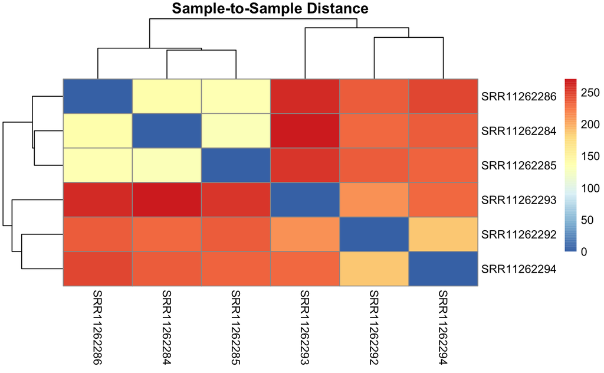

```r
d <- dist(t(mat))
pheatmap(as.matrix(d),
         clustering_distance_rows = d,
         clustering_distance_cols = d,
         main = "Sample-to-Sample Distance")
```

#### PCA

PCA reduces thousands of gene expression values into principal components that capture the majority of variance. This helps visualize how distinct your experimental groups are. Samples should ideally separate along PC1 or PC2 according to their experimental condition.

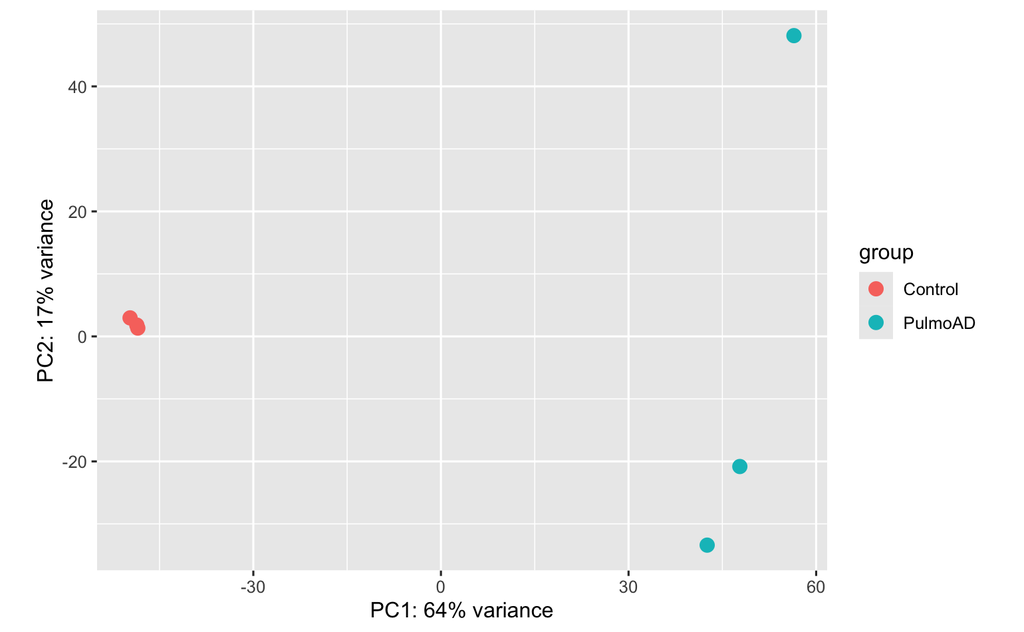

```r
plotPCA(dds_rlog, intgroup = "Group")
```

#### Sample Coorrelation

Calculates Pearson correlations between samples. High correlation among replicates indicates good data quality.

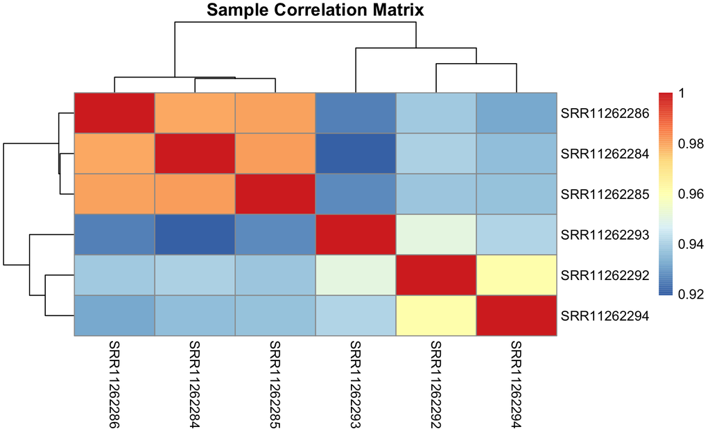

```r
cor.mat <- cor(mat)
pheatmap(cor.mat, main = "Sample Correlation Matrix")
```

### 10. Run DESeq2 pipeline

This step executes the main DESeq2 pipeline, including: Estimating size factors (normalization), Estimating gene-wise dispersion, Fitting the negative binomial model and Performing hypothesis testing for differential expression.

This is the core computational step where DESeq2 identifies genes whose expression differs significantly between conditions.

```r
dds <- DESeq(dds)
```

### 11. Extract results

This step extracts statistical results for each gene, ordered by adjusted p-value (FDR). Then, maps Ensembl IDs to human-readable gene symbols for clarity. The output provides for each gene: log2FoldChange - magnitude of expression change, p-value - statistical significance, padj (FDR) - false discovery rate–adjusted significance.

A negative log2FoldChange means downregulation in PulmoAD; a positive one indicates upregulation.

```r
#Extract results of disease vs control
res <- results(dds, contrast = c("Group", "PulmoAD", "Control"))
res
```

```
log2 fold change (MLE): Group PulmoAD vs Control
Wald test p-value: Group PulmoAD vs Control
DataFrame with 28582 rows and 6 columns
                 baseMean log2FoldChange     lfcSE      stat      pvalue        padj
                <numeric>      <numeric> <numeric> <numeric>   <numeric>   <numeric>
ENSG00000160072 1606.6916      2.2674307  0.581658  3.898217 9.69037e-05  0.00136711
ENSG00000228037   10.5689      0.6380314  1.118450  0.570460 5.68366e-01  0.76918747
ENSG00000142611  263.0978     -2.9425217  0.877859 -3.351931 8.02500e-04  0.00794075
ENSG00000157911  648.5029      0.0793563  0.479658  0.165443 8.68595e-01  0.94085199
ENSG00000269896   45.5117      0.7141019  0.911673  0.783287 4.33458e-01  0.66725575
...                   ...            ...       ...       ...         ...         ...
ENSG00000276345 295.71364      -1.352923  1.091614  -1.23938 2.15205e-01 4.52904e-01
ENSG00000275063  92.45127       6.575334  0.984225   6.68072 2.37764e-11 1.61645e-09
ENSG00000277856 171.07108       8.497180  2.340048   3.63120          NA          NA
ENSG00000271254 253.33253      -0.999847  0.676252  -1.47851 1.39271e-01 3.48162e-01
ENSG00000277475   3.21461      -3.216015  2.611189  -1.23163 2.18088e-01          NA
```

```r
#Check result column description
mcols(res, use.names=TRUE)
```

```
DataFrame with 6 rows and 2 columns
                       type            description
                <character>            <character>
baseMean       intermediate mean of normalized c..
log2FoldChange      results log2 fold change (ML..
lfcSE               results standard error: Grou..
stat                results Wald statistic: Grou..
pvalue              results Wald test p-value: G..
padj                results   BH adjusted p-values
```

```r
# Order results by adjusted p-value
resOrdered <- res[order(res$padj), ]
resOrdered
```

```
log2 fold change (MLE): Group PulmoAD vs Control
Wald test p-value: Group PulmoAD vs Control
DataFrame with 28582 rows and 6 columns
                 baseMean log2FoldChange     lfcSE      stat      pvalue        padj
                <numeric>      <numeric> <numeric> <numeric>   <numeric>   <numeric>
ENSG00000168484 369716.74      -10.71906  0.547259  -19.5868 2.00312e-85 4.73919e-81
ENSG00000204305  42687.55       -8.26545  0.465328  -17.7626 1.37644e-70 1.62826e-66
ENSG00000066405  11522.22       -9.22597  0.644189  -14.3218 1.59865e-46 1.26075e-42
ENSG00000196616  11928.84       -8.86138  0.627820  -14.1145 3.09132e-45 1.82844e-41
ENSG00000108576   2693.22       -8.98368  0.648450  -13.8541 1.20194e-43 5.68734e-40
...                   ...            ...       ...       ...         ...         ...
ENSG00000273554   3.31241        3.27206   2.29843  1.423607   0.1545603          NA
ENSG00000277836   3.20684        5.17672   2.65885  1.946976   0.0515376          NA
ENSG00000278066   2.19428        1.22947   2.45206  0.501404   0.6160867          NA
ENSG00000277856 171.07108        8.49718   2.34005  3.631199          NA          NA
ENSG00000277475   3.21461       -3.21601   2.61119 -1.231629   0.2180878          NA
```

```r
# Remove Ensembl version numbers if present
ensembl_ids <- gsub("\\..*", "", rownames(resOrdered))
```

```r
# Map Ensembl IDs to gene symbols
gene_symbols <- mapIds(org.Hs.eg.db,
                       keys = ensembl_ids,
                       column = "SYMBOL",
                       keytype = "ENSEMBL",
                       multiVals = "first")
```

```r
# Replace Ensembl IDs with gene names (fallback to Ensembl if missing)
rownames(resOrdered) <- ifelse(!is.na(gene_symbols) & gene_symbols != "",
                               gene_symbols,
                               ensembl_ids)


head(resOrdered)
```

```
log2 fold change (MLE): Group PulmoAD vs Control
Wald test p-value: Group PulmoAD vs Control
DataFrame with 6 rows and 6 columns
        baseMean log2FoldChange     lfcSE      stat      pvalue        padj
       <numeric>      <numeric> <numeric> <numeric>   <numeric>   <numeric>
SFTPC  369716.74      -10.71906  0.547259  -19.5868 2.00312e-85 4.73919e-81
AGER    42687.55       -8.26545  0.465328  -17.7626 1.37644e-70 1.62826e-66
CLDN18  11522.22       -9.22597  0.644189  -14.3218 1.59865e-46 1.26075e-42
ADH1B   11928.84       -8.86138  0.627820  -14.1145 3.09132e-45 1.82844e-41
SLC6A4   2693.22       -8.98368  0.648450  -13.8541 1.20194e-43 5.68734e-40
CLIC5    7262.06       -6.82354  0.502145  -13.5888 4.66804e-42 1.84069e-38
```

```r
#Check Duplicates
sum(duplicated(rownames(resOrdered)))
```

```
[1] 38
```

```r
#remove duplicates
resOrdered <- resOrdered[!duplicated(rownames(resOrdered)), ]
resOrdered
```

```
log2 fold change (MLE): Group PulmoAD vs Control
Wald test p-value: Group PulmoAD vs Control
DataFrame with 28544 rows and 6 columns
                 baseMean log2FoldChange     lfcSE      stat      pvalue        padj
                <numeric>      <numeric> <numeric> <numeric>   <numeric>   <numeric>
SFTPC           369716.74      -10.71906  0.547259  -19.5868 2.00312e-85 4.73919e-81
AGER             42687.55       -8.26545  0.465328  -17.7626 1.37644e-70 1.62826e-66
CLDN18           11522.22       -9.22597  0.644189  -14.3218 1.59865e-46 1.26075e-42
ADH1B            11928.84       -8.86138  0.627820  -14.1145 3.09132e-45 1.82844e-41
SLC6A4            2693.22       -8.98368  0.648450  -13.8541 1.20194e-43 5.68734e-40
...                   ...            ...       ...       ...         ...         ...
ENSG00000273554   3.31241        3.27206   2.29843  1.423607   0.1545603          NA
ENSG00000277836   3.20684        5.17672   2.65885  1.946976   0.0515376          NA
ENSG00000278066   2.19428        1.22947   2.45206  0.501404   0.6160867          NA
ENSG00000277856 171.07108        8.49718   2.34005  3.631199          NA          NA
ENSG00000277475   3.21461       -3.21601   2.61119 -1.231629   0.2180878          NA
```

```r
# Save results (optional)
write.csv(as.data.frame(resOrdered), file = "DESeq2_results_Unfiltered.csv")
```

### 12. Identify Sig DEGs

Selects significantly differentially expressed genes using statistical and biological cutoffs: Adjusted p-value < 0.05 (statistical confidence) and |log2FoldChange| > 1 (≥2-fold change)

```r
sig_DEGs <- resOrdered[
  !is.na(resOrdered$padj) &
    resOrdered$padj < 0.05 &
    abs(resOrdered$log2FoldChange) > 1, ]

head(sig_DEGs)
```

```
log2 fold change (MLE): Group PulmoAD vs Control
Wald test p-value: Group PulmoAD vs Control
DataFrame with 6 rows and 6 columns
        baseMean log2FoldChange     lfcSE      stat      pvalue        padj
       <numeric>      <numeric> <numeric> <numeric>   <numeric>   <numeric>
SFTPC  369716.74      -10.71906  0.547259  -19.5868 2.00312e-85 4.73919e-81
AGER    42687.55       -8.26545  0.465328  -17.7626 1.37644e-70 1.62826e-66
CLDN18  11522.22       -9.22597  0.644189  -14.3218 1.59865e-46 1.26075e-42
ADH1B   11928.84       -8.86138  0.627820  -14.1145 3.09132e-45 1.82844e-41
SLC6A4   2693.22       -8.98368  0.648450  -13.8541 1.20194e-43 5.68734e-40
CLIC5    7262.06       -6.82354  0.502145  -13.5888 4.66804e-42 1.84069e-38
```

```r
# Seperate Up and Down Significant DEGs
up_genes <- sig_DEGs[sig_DEGs$log2FoldChange > 1, ]
up_genes <- up_genes[order(up_genes$log2FoldChange, decreasing = TRUE), ]
up_genes
```

```
log2 fold change (MLE): Group PulmoAD vs Control
Wald test p-value: Group PulmoAD vs Control
DataFrame with 1925 rows and 6 columns
                 baseMean log2FoldChange     lfcSE      stat      pvalue        padj
                <numeric>      <numeric> <numeric> <numeric>   <numeric>   <numeric>
ENSG00000223812   15.7917        20.6143   3.90971   5.27259 1.34514e-07 4.30063e-06
LY6D            2982.0499        15.0310   3.16035   4.75611 1.97360e-06 4.83368e-05
CASP14          2206.1438        14.5962   2.88698   5.05588 4.28409e-07 1.22560e-05
DSG3            1269.4033        13.7990   1.57151   8.78074 1.62402e-18 3.84226e-16
SERPINB4        1455.7770        13.0346   2.30395   5.65749 1.53601e-08 5.96723e-07
...                   ...            ...       ...       ...         ...         ...
REEP4             1100.99        1.16456  0.427793   2.72226  0.00648373   0.0405388
TBL1XR1           3459.49        1.14272  0.424152   2.69414  0.00705706   0.0432996
RPN2              8732.88        1.13026  0.412011   2.74327  0.00608307   0.0386886
HNRNPA2B1        16056.80        1.11934  0.416472   2.68768  0.00719514   0.0440325
MTA2              3579.72        1.11765  0.421006   2.65472  0.00793742   0.0475662
```

```r
down_genes <- sig_DEGs[sig_DEGs$log2FoldChange < -1, ]
down_genes <- down_genes[order(down_genes$log2FoldChange, decreasing = FALSE), ]
down_genes
```

```
log2 fold change (MLE): Group PulmoAD vs Control
Wald test p-value: Group PulmoAD vs Control
DataFrame with 2086 rows and 6 columns
                  baseMean log2FoldChange     lfcSE      stat      pvalue        padj
                 <numeric>      <numeric> <numeric> <numeric>   <numeric>   <numeric>
AGTR2              265.079       -11.4468  1.521199  -7.52488 5.27688e-14 5.94503e-12
SFTPC           369716.735       -10.7191  0.547259 -19.58682 2.00312e-85 4.73919e-81
ENSG00000231322    142.730       -10.5539  1.424953  -7.40651 1.29667e-13 1.40724e-11
LGI3               804.106       -10.2613  1.011444 -10.14519 3.48108e-24 1.68079e-21
C8B                112.479       -10.2096  1.499320  -6.80946 9.79654e-12 7.10971e-10
...                    ...            ...       ...       ...         ...         ...
NR3C1              3171.10       -1.21695  0.428064  -2.84292  0.00447022   0.0305933
TLE5              12694.66       -1.21257  0.410317  -2.95520  0.00312463   0.0232324
ST3GAL4            1362.14       -1.18055  0.427702  -2.76022  0.00577629   0.0372780
CREBL2             2171.67       -1.17749  0.433975  -2.71327  0.00666235   0.0414365
ARL5A              1439.93       -1.13866  0.430377  -2.64572  0.00815173   0.0485920
```

```r
write.csv(as.data.frame(up_genes), "PulmoAD_Sig_DEGs_up.csv")
write.csv(as.data.frame(down_genes), "PulmoAD_Sig_DEGs_down.csv")
```

### 13. Visualize the result

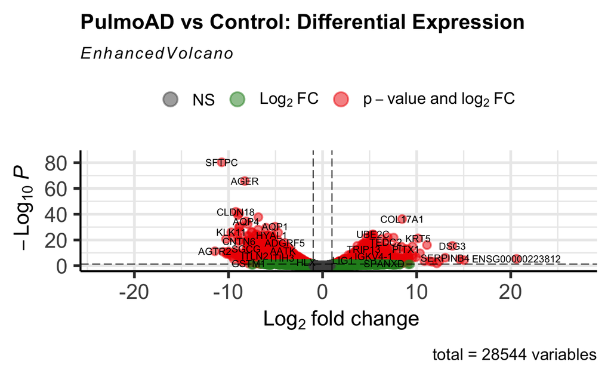

```r
# Volcano plot
EnhancedVolcano(resOrdered,
                lab = rownames(resOrdered),
                x = 'log2FoldChange',
                y = 'padj',
                title = 'PulmoAD vs Control: Differential Expression',
                pCutoff = 0.05,
                FCcutoff = 1,
                pointSize = 2.5,
                labSize = 3)
```

```r
#SessionInfo
sessionInfo()
```

[output not shown]